# Colossal cloves

# Garden vs store varieties

Most grocery stores sell softneck varieties of garlic, with many small cloves.

My coworker gave me a hardneck garlic variety that consistently produces six large cloves per bulb.

Let’s compare them. Along the way, we’ll also make a file for storing our data for future seasons.

### Home-grown cloves

```r
home_grams <- c(8, 17, 14, 20, 13, 13, 11, 15, 11,
                10, 19, 19, 19, 13, 17, 13, 15, 11,
                12, 19, 14, 13, 21, 8, 5, 13, 12, 13,
                17, 9, 8, 17, 9, 20, 7, 13)
```

### Summary of home-grown cloves

```r
options(digits = 2) #set precision of printed numbers
summary(home_grams)
```

```
##    Min. 1st Qu.  Median    Mean 3rd Qu.    Max.
##     5.0    11.0    13.0    13.6    17.0    21.0
```

## Store-bought cloves

Since the cloves are replanted the same year the bulbs are harvested, I can use “year” to keep track of each generation. The 2023 cloves produced the 2024 bulbs which I “cracked” to get the 2024 cloves. Those will produce the 2025 bulbs, which…

```r
store_grams <- c(5, 2, 4, 3, 3, 8, 4, 3, 9, 4, 3, 2,
                 4, 4, 2, 2, 2, 3, 2, 2, 1, 1, 1)
summary(store_grams)
```

```
##    Min. 1st Qu.  Median    Mean 3rd Qu.    Max.
##     1.0     2.0     3.0     3.2     4.0     9.0
```

## Comparison home-grown vs store bought (hardneck vs softneck)

We can compare two boxplots next to each other to compare the two garlic types

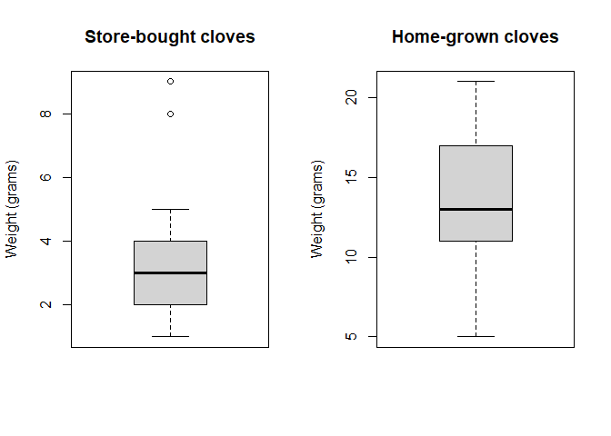

```r
par(mfrow = c(1, 2)) #frame plots in 1 row w/ 2 cols
boxplot(store_grams, ylab = "Weight (grams)")
title("Store-bought cloves")
boxplot(home_grams, ylab = "Weight (grams)")
title("Home-grown cloves")
```

### Structured data

The plots look great, but we had to write the code twice. As this project continues, I’ll need to add new plots for each harvest.

It’s not too much work, but after a few years that will be a lot of code to track. And since it is only once a year, I’ll probably forget some of the details.

Instead, I can create a data structure that allows the plots to update every time I add new data.

```r
garlic_data <- data.frame(weight = c(home_grams, store_grams),
                          year = rep(2024, times = length(c(home_grams,
                                                            store_grams))),
                          source = c(rep("home", times = length(home_grams)),
                                     rep("store", times = length(store_grams))))

head(garlic_data)
```

```
##   weight year source
## 1      8 2024   home
## 2     17 2024   home
## 3     14 2024   home
## 4     20 2024   home
## 5     13 2024   home
## 6     13 2024   home
```

```r
tail(garlic_data)
```

```
##    weight year source
## 54      3 2024  store
## 55      2 2024  store
## 56      2 2024  store
## 57      1 2024  store
## 58      1 2024  store
## 59      1 2024  store
```

### Long-form data

In this format (called long format), each row represents an individual and each column represents a measurement of a property (weight, year, source).

It might be tempting to have a column for store-bought cloves and a column for home-grown cloves. This spreads the weights over two columns, one if it’s from the store, another if it’s homegrown. It’s better to have all the weights in one column, because R expects a 1:1 property-to-column ratio.

Long format has many advantages when it comes to built-in features in R.

### Formulas in R

Using “long-form” data, we can take advantage of formulas in R.

This formula (saved inside the “garlic_formula” variable), can be used to tell functions to report the weights grouped by the source and year.

```r
garlic_formula <- weight ~ source + year
```

Many functions work with formulas to automatically “break down” the data in one column based on other columns.

Boxplot takes the instructions from the formula and breaks down the weight data by the other columns.

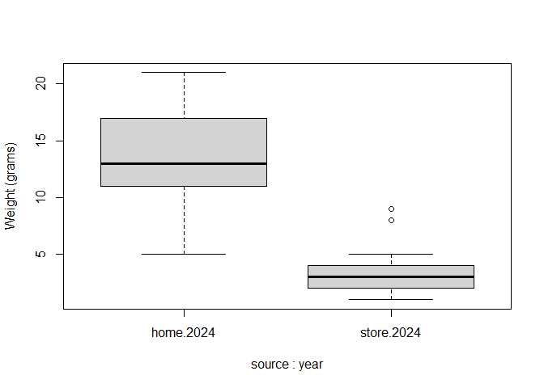

```r
boxplot(data = garlic_data, garlic_formula, ylab = "Weight (grams)")
```

```r
aggregate(data = garlic_data, garlic_formula,
          FUN = summary, digits = 2) #digits is passed to the summary function
```

```
##   source year weight.Min. weight.1st Qu. weight.Median weight.Mean
## 1   home 2024         5.0           11.0          13.0        14.0
## 2  store 2024         1.0            2.0           3.0         3.2
##   weight.3rd Qu. weight.Max.
## 1           17.0        21.0
## 2            4.0         9.0
```

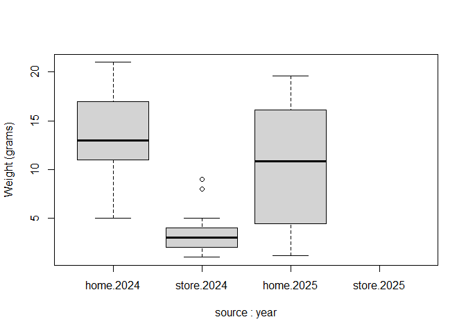

```r
#create example future data set
example_future <- data.frame("weight" = runif(25, 1, 20),
                             "year" = rep(2025, times = 25),
                             "source" = rep("home", times = 25)
)


#append future data to past data
updated_garlic <- rbind(garlic_data, example_future)

#see how updating the data updates the plot without changing the code
boxplot(data = updated_garlic, garlic_formula, ylab = "Weight (grams)")
```

# Conclusions

The cloves are more than 4 times as big! That’s lot easier to handle when cooking for a family.

### Saving data for next year

I plan on measuring my home-grown cloves each year, but not measuring store-bought cloves.

The dplyr package provides an excellent paradigm for filtering and selecting data.

```r
require("dplyr")
keep_data <- updated_garlic %>%
  filter(source == "home" & year == 2024) %>%
  select(!source)
```

As you can see from the summary below, I’ve only kept the data for the 2024 home-grown cloves, and I’m no longer tracking the source (since I’ll only be tracking home-grown cloves).

```r
summary(keep_data)
```

```
##      weight          year
##  Min.   : 5.0   Min.   :2024
##  1st Qu.:11.0   1st Qu.:2024
##  Median :13.0   Median :2024
##  Mean   :13.6   Mean   :2024
##  3rd Qu.:17.0   3rd Qu.:2024
##  Max.   :21.0   Max.   :2024
```